# California Housing price regression and Ceteris Paribus

The report describes XGBoost and Multi Layer Perceptron learning results on California Housing dataset and decomposition of trained models sample predictions using Ceteris Paribus. The dataset contains 8 features describing blocks of houses. MedHouseVal is an explained variable containing medium house value in $100 000. Below there are quartiles for all of the features. Some features like "average number of rooms" may take very large values because the dataset contains also vacation resorts data.

|  | MedInc | HouseAge | AveRooms | AveBedrms | Population | AveOccup | Latitude | Longitude |
| --- | --- | --- | --- | --- | --- | --- | --- | --- |
| **0.00** | 0.50 | 1.0 | 0.89 | 0.33 | 3.0 | 0.69 | 32.55 | -124.35 |
| **0.25** | 2.57 | 18.0 | 4.45 | 1.01 | 789.0 | 2.43 | 33.93 | -121.81 |
| **0.50** | 3.55 | 29.0 | 5.24 | 1.05 | 1167.0 | 2.82 | 34.26 | -118.51 |
| **0.75** | 4.77 | 37.0 | 6.06 | 1.10 | 1726.0 | 3.28 | 37.72 | -118.01 |
| **1.00** | 15.00 | 52.0 | 141.91 | 25.64 | 35682.0 | 1243.33 | 41.95 | -114.31 |

XGBoost model was trained with 1000 estimators, max depth equal to 5 and default settings from sklearn. On a validation set it got the following statistics: MSE=0.20, R^2=0.84. Below there are validation results:

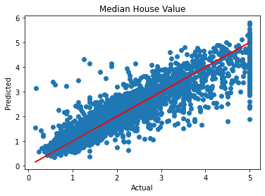

I have chosen 2 observations: with the 50th lowest and with the 50th largest price. The table below shows the observations with prediction results from XGBoost model. As we can see, the error is less than 12%.

| MedInc | HouseAge | AveRooms | AveBedrms | Population | AveOccup | Latitude | Longitude | MedHouseVal | XGBPred |
| --- | --- | --- | --- | --- | --- | --- | --- | --- | --- |
| 1.73 | 47.0 | 4.38 | 0.99 | 949.0 | 2.92 | 36.76 | -119.78 | 0.51 | 0.48 |
| 7.28 | 27.0 | 7.76 | 1.44 | 594.0 | 1.82 | 32.86 | -117.25 | 5.00 | 5.56 |

Below there is a decomposition of selected predictions using Ceteris Paribus for house age, average number of bedrooms, latitude and longitude. The first four figures show median house value for changes in one feature for observation with lower price. As we can see, house age does not influence the price too much. Only age lower than 2 years would increse the price of houses in the block. The plot with average number of bedrooms makes sense only for less than 5, because average number of rooms is less than 5. If there were more or less bedrooms than in reality, the price would be higher. Latitude and longitude have the largest impact on price for this observation and change in latitude could increse the price even more than 10 times.

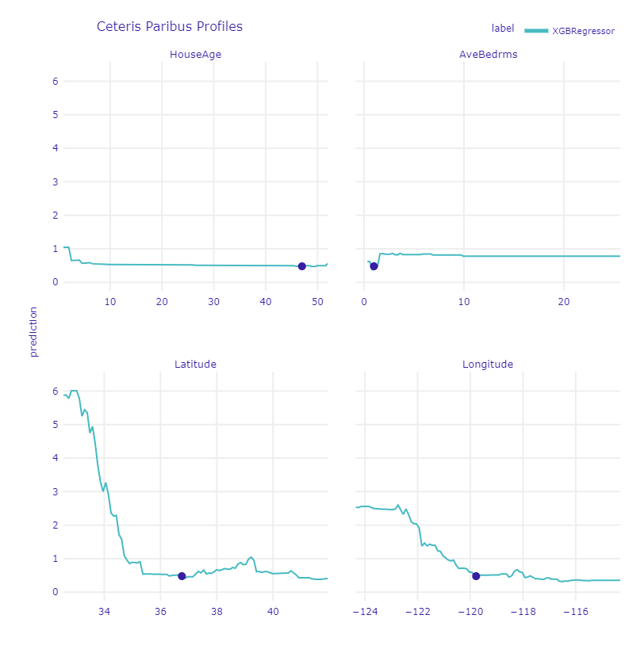

The next four figures show decomposition for the higher price. Similarily to the previous case, changes in coordinates would influence the price the most. The largest difference there is for the house age feature. If there was similar house in the same location, the same number of rooms and other similar features which has been built more recently, then its price would be lower. It is quite surprising because newer houses should be more expensive. Possible hypothesis is that newer houses built in this place are less equipped.

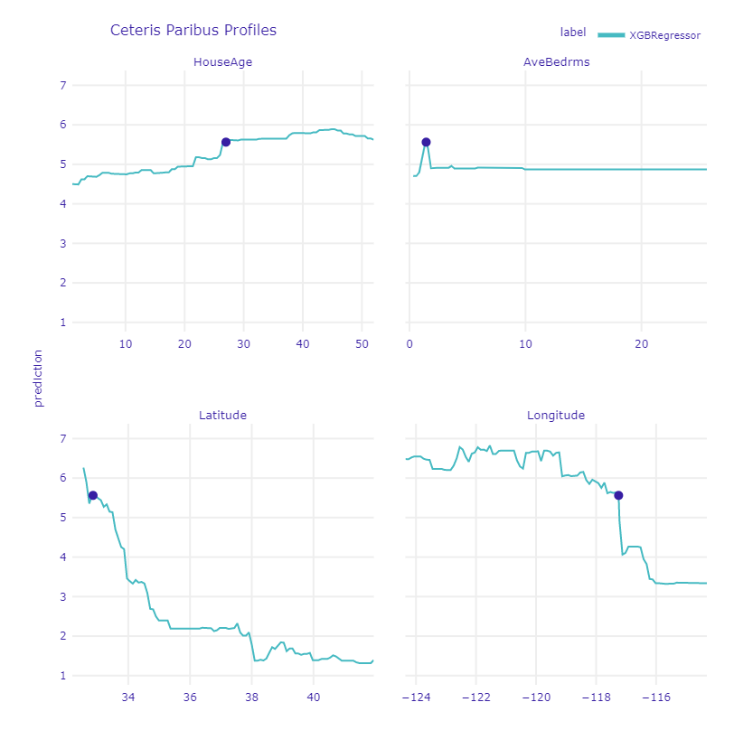

The second trained model was MLP with 3 hidden layers (64, 64, 64). These are its results on a validation set: MSE=0.28, R^2=0.79, and all predictions on this set below:

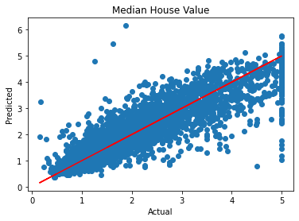

Below there are the same 2 selected observations with MLP prediction results:

| MedInc | HouseAge | AveRooms | AveBedrms | Population | AveOccup | Latitude | Longitude | MedHouseVal | MLPPred |
| --- | --- | --- | --- | --- | --- | --- | --- | --- | --- |
| 1.73 | 47.0 | 4.38 | 0.99 | 949.0 | 2.92 | 36.76 | -119.78 | 0.51 | 0.61 |
| 7.28 | 27.0 | 7.76 | 1.44 | 594.0 | 1.82 | 32.86 | -117.25 | 5.00 | 5.11 |

Below there are results of a similar Ceteris Paribus decomposition for the lower and higher price (in this order), but using MLP model. As we can see, changes in location would also influence the price significantly for this model. However, there is a difference for the average number of bedrooms, especially for the observation with higher price. The price was nearly constant for any number of bedrooms more than 2 for the previous model. In the case with MLP model and the observation with higher price, for more than 2 bedrooms, the more bedrooms, the lower prediction result. Possible hypothesis is that higher difference between number of rooms and number of bedrooms could be more important than higher raw number of bedrooms. The higher the difference, the more guest and living rooms there are in a house.

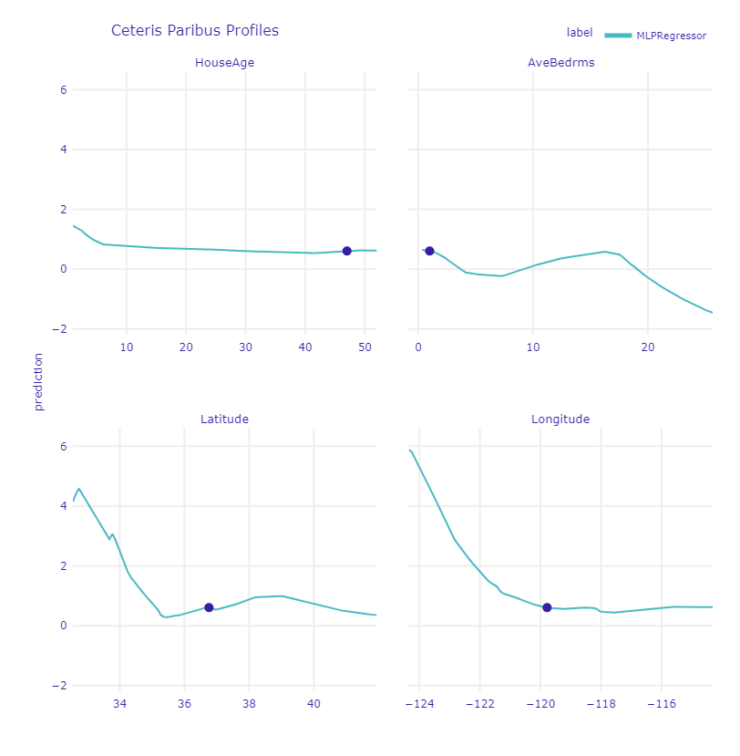

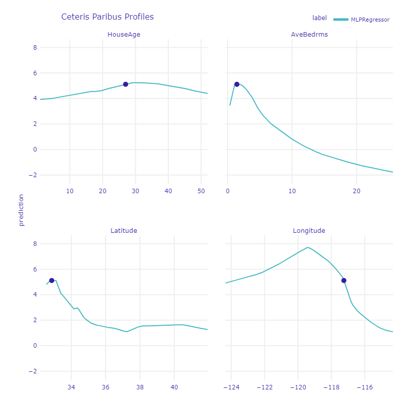

## Appendix

```python
from matplotlib import pyplot
import dalex as dx
from xgboost import XGBRegressor

from sklearn import metrics
from sklearn.model_selection import train_test_split
from sklearn.datasets import fetch_california_housing
from sklearn.preprocessing import MinMaxScaler
from sklearn.pipeline import make_pipeline
from sklearn.neural_network import MLPRegressor

def evaluate(testY, predY):
    pyplot.plot(testY, testY, 'r')
    pyplot.scatter(testY, predY)
    pyplot.title('Median House Value');
    pyplot.xlabel('Actual')
    pyplot.ylabel('Predicted')
    pyplot.show()

    print()
    print("MSE:", metrics.mean_squared_error(testY, predY))
    print("MAE:", metrics.mean_absolute_error(testY, predY))
    print("R2:", metrics.r2_score(testY, predY))
```

### Data loading

```python
X, y = fetch_california_housing(return_X_y=True, as_frame=True)
X_train, X_test, y_train, y_test = train_test_split(X, y, test_size=0.2, random_state=42)
```

```python
print('features:', X_train.shape[1])
print('X_train length:', X_train.shape[0])
print('X_test length:', X_test.shape[0])
```

```python
X_train.quantile([i / 4 for i in range(5)]).round(2)
```

### Training

#### XGBoost Regressor

```python
model_XGB = XGBRegressor(objective='reg:squarederror', n_estimators=1000, max_depth=5)
model_XGB.fit(X_train, y_train)
y_pred = model_XGB.predict(X_test)
evaluate(y_test, y_pred)
```

#### Multi Layer Perceptron

```python
model_MLP = make_pipeline(MinMaxScaler(), MLPRegressor((64, 64, 64), learning_rate='adaptive', max_iter=1000))
model_MLP.fit(X_train, y_train)
y_pred = model_MLP.predict(X_test)
evaluate(y_test, y_pred)
```

### Selecting observations

```python
data = X_test.copy()
data['MedHouseVal'] = y_test
data_selected = data.sort_values('MedHouseVal').iloc[[50, -50]]
X_selected = data_selected[X_test.columns]
data_selected['XGBPred'] = model_XGB.predict(X_selected)
data_selected['MLPPred'] = model_MLP.predict(X_selected)
XGB_selected = data_selected[list(data.columns) + ['XGBPred']]
MLP_selected = data_selected[list(data.columns) + ['MLPPred']]
```

```python
XGB_selected.round(2)
```

```python
MLP_selected.round(2)
```

### Ceteris Paribus

#### XGBoost

```python
explainer_XGB = dx.Explainer(model_XGB, X_train, y_train)

for i in range(len(X_selected)):
    cp = explainer_XGB.predict_profile(X_selected.iloc[i])
    cp.plot(variables=['HouseAge', 'AveBedrms', 'Latitude', 'Longitude'])
```

#### Multi Layer Perceptron

```python
explainer_MLP = dx.Explainer(model_MLP, X_train, y_train)

for i in range(len(X_selected)):
    cp = explainer_MLP.predict_profile(X_selected.iloc[i])
    cp.plot(variables=['HouseAge', 'AveBedrms', 'Latitude', 'Longitude'])
```